# Analysis of Alena Shkumatava miRNASeq Data

Anton Enright

2018-01-09

# Experiment Setup

All data were pre-processed using *minion* to identify and check adapters, *reaper* to trim adapter sequences followed by *tally* to deduplicate reads while maintaining depth information. Subsequent to this all reads passed through the *mirmod* pipeline against all miRBase (Release 21) precursor sequences for Mouse and Zebrafish. Reads were summed across paired end sequences for the same read pair. Finally reads are loaded into R for final analysis.

This is the sample description file used for the analyses below.

| **Name** | **File** | **Barcodes** | **3p_ad** |
| --- | --- | --- | --- |
| wt1 | A638S1.R1.fastq.gz | no_barcode | AGATCGGAAGAGCACA |
| wt2 | A638S2.R1.fastq.gz | no_barcode | AGATCGGAAGAGCACA |
| wt3 | A638S3.R1.fastq.gz | no_barcode | AGATCGGAAGAGCACA |
| mt1 | A638S4.R1.fastq.gz | no_barcode | AGATCGGAAGAGCACA |
| mt2 | A638S5.R1.fastq.gz | no_barcode | AGATCGGAAGAGCACA |
| mt3 | A638S6.R1.fastq.gz | no_barcode | AGATCGGAAGAGCACA |

## Preparation

We first load the R/BioConductor libraries that we need.

```r
library(RColorBrewer)
library(gplots)
library(DESeq2)
library(reshape2)
library(ggplot2)
hmcol = colorRampPalette(brewer.pal(9, "GnBu"))(100)
spectral <- colorRampPalette(rev(brewer.pal(11, "Spectral")), space="Lab")(100)
```

# Mouse Analysis

## Count Loading

We can now load all the count data

```r
setwd("/Users/aje/anton_r_notebook/alena_mirna_oct_2016/")
mircounts <- read.table("mouse_counts_mar_2017.txt",header=TRUE,row.names=1)
mircounts=mircounts[-nrow(mircounts),]
```

As well as the pdata, which contains information on each sample.

```r
pdata <- read.table("pdata_mar_2017.txt",header=TRUE,row.names=1)

#pdata=pdata[c(1,2,5,6),]
#mircounts=mircounts[,c(1,2,5,6)]

colnames(mircounts)=rownames(pdata)

conds=as.factor(as.character(pdata$Genotype))
```

## Count Preparation & Normalisation

We are now ready to create a DESeq object from the counts table.

```r
#Lets Load the Counts First
coldata = as.data.frame(t(t(conds)))
rownames(coldata)=colnames(mircounts)
colnames(coldata)='treatment'
dds <- DESeqDataSetFromMatrix(countData = mircounts, colData = coldata, design = ~ treatment)
```

We are ready to normalise the data, but first we should look at the number of sequenced reads per sample.

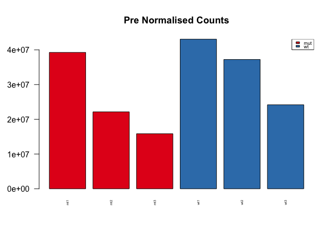

```r
cond_colours = c("#E41A1C","#377EB8")[as.factor(conds)]
names(cond_colours)=conds

group_colours = brewer.pal(length(rownames(pdata)),"Accent")[as.factor(rownames(pdata))]
names(group_colours)=rownames(pdata)

quartz()
barplot(apply(mircounts,2,sum), las=2,col=cond_colours,main="Pre Normalised Counts",cex.names=0.4)
legend("topright",levels((conds)),cex=0.6,fill=cond_colours[levels(conds)])
```

We will also estimate the negative binomial dispersion of the data.

```r
dds <- estimateSizeFactors(dds)
dds <- estimateDispersions(dds)
```

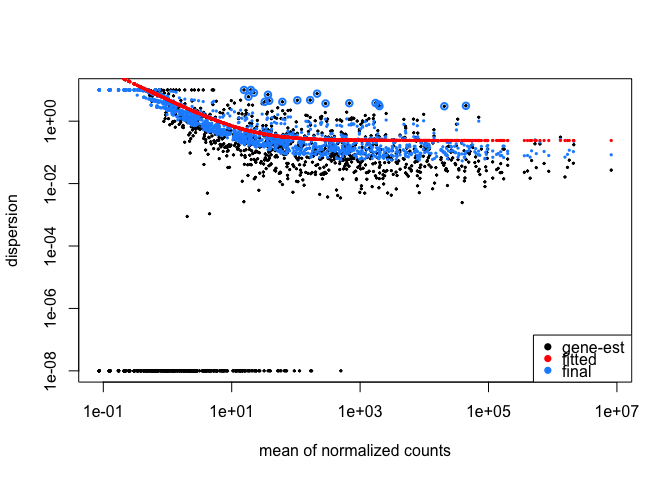

```r
quartz()
plotDispEsts(dds)
```

## Post Normalisation QC

Now we can normalise and plot the counts again.

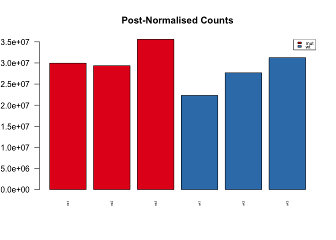

```r
normcounts <- counts(dds, normalized=TRUE)
rawcounts=counts(dds,normalized=FALSE)
log2counts=log2(normcounts+1)


quartz()
barplot(apply(normcounts,2,sum), las=2,col=cond_colours,main="Post-Normalised Counts",cex.names=0.4)
legend("topright",levels((conds)),cex=0.6,fill=cond_colours[levels(conds)])
```

We will apply the Variance Stabilising Transformation (VST) it’s better than log2 for counts.

```r
vsd <- varianceStabilizingTransformation(dds)
vstcounts <- assay(vsd)
vstcounts <- vstcounts[order(apply(vstcounts,1,sum),decreasing =TRUE),]
```

As an additional QC step we can calculate the sample-to-sample Pearson correlations and plot them in a heatmap.

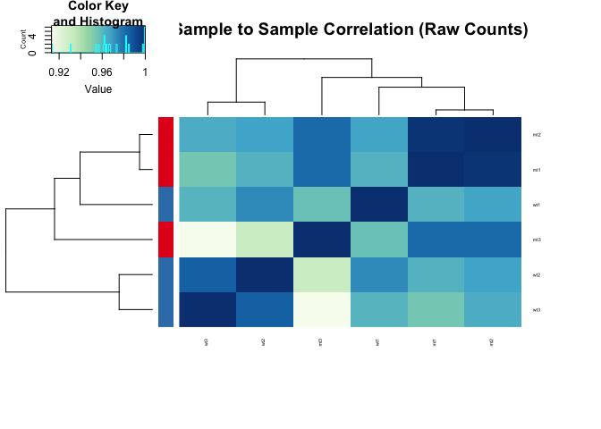

```r
quartz()
heatmap.2(cor(rawcounts),trace="none",col=hmcol,main="Sample to Sample Correlation (Raw Counts)",cexRow=0.5,cexCol=0.5,RowSideColors=cond_colours, margins=c(9,7))
```

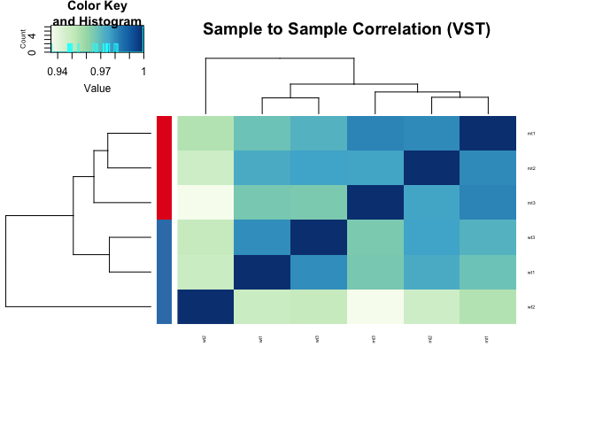

```r
quartz()
heatmap.2(cor(vstcounts),trace="none",col=hmcol,main="Sample to Sample Correlation (VST)",cexRow=0.5,cexCol=0.5,RowSideColors=cond_colours,margins=c(9,7))
```

We can also perform PCA.

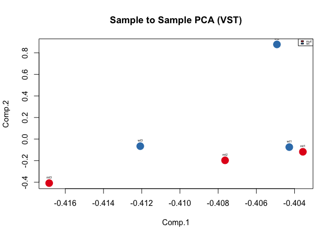

```r
pca <- princomp(vstcounts)


quartz()
plot(pca$loadings, col=cond_colours,  pch=19, cex=2, main="Sample to Sample PCA (VST)")
text(pca$loadings, as.vector(colnames(mircounts)), pos=3, cex=0.4)
legend("topright",levels(conds),fill=cond_colours[levels(conds)],cex=0.4)
```

PCA of the top 3 Principal Components.

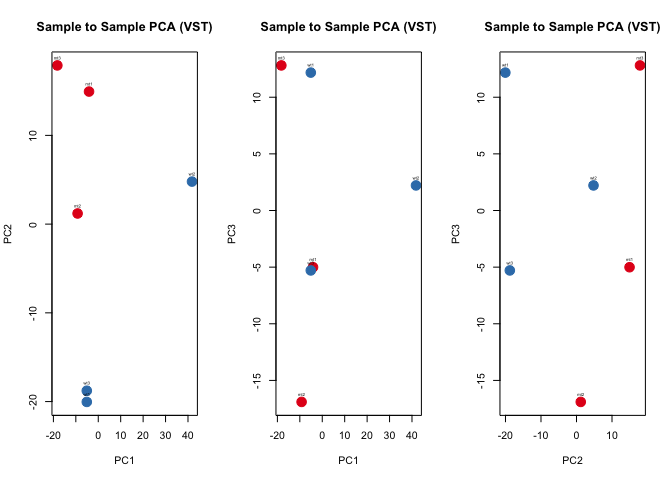

```r
pca2=prcomp(t(vstcounts),center=TRUE)

quartz()
par(mfrow=c(1,3))
plot(pca2$x, col=cond_colours,  pch=19, cex=2, main="Sample to Sample PCA (VST)")
text(pca2$x, as.vector(colnames(mircounts)), pos=3, cex=0.4)
plot(pca2$x[,1],pca2$x[,3], col=cond_colours,  pch=19, cex=2, main="Sample to Sample PCA (VST)",ylab="PC3",xlab="PC1")
text(pca2$x[,1],pca2$x[,3], as.vector(colnames(mircounts)), pos=3, cex=0.4)
plot(pca2$x[,2],pca2$x[,3], col=cond_colours,  pch=19, cex=2, main="Sample to Sample PCA (VST)",ylab="PC3",xlab="PC2")
text(pca2$x[,2],pca2$x[,3], as.vector(colnames(mircounts)), pos=3, cex=0.4)
```

## Initial Biological Analysis of the data

Here are the top10 microRNAs.

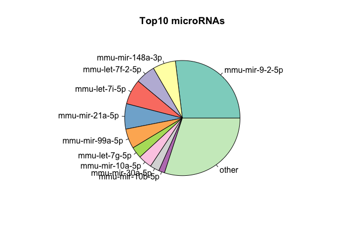

```r
top10=apply(mircounts,1,sum)[1:10]
top10[11]=sum(apply(mircounts,1,sum)[11:nrow(mircounts)])
names(top10)[11]="other"
pie(top10,col=brewer.pal(11,"Set3"),main="Top10 microRNAs")
```

This is the expression of the top10 microRNAs sample to sample.

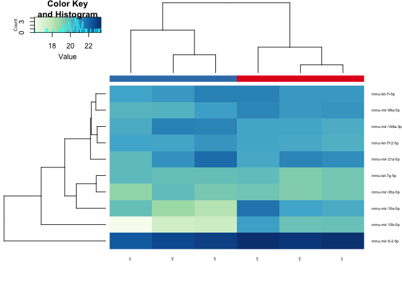

```r
heatmap.2(vstcounts[names(top10)[1:10],],col=hmcol,trace="none",cexCol=0.4,cexRow=0.6,ColSideColors=cond_colours)
```

This is the expression of the miR-29 families of microRNAs sample to sample.

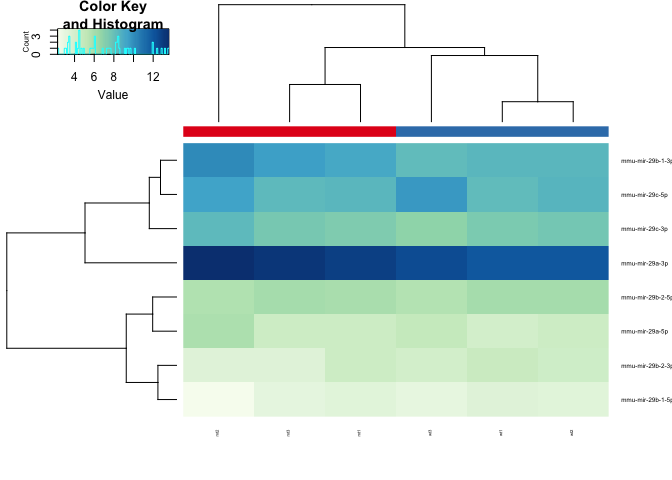

```r
heatmap.2(vstcounts[rownames(mircounts)[grep("mir-29[a-z]",rownames(mircounts))],],col=hmcol,trace="none",cexCol=0.4,cexRow=0.6,ColSideColors=cond_colours)
```

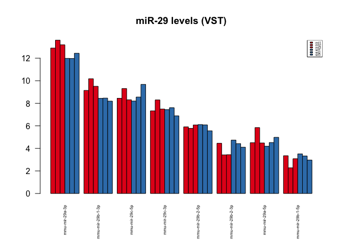

```r
quartz()
barplot(t(vstcounts[rownames(mircounts)[grep("mir-29[a-z]",rownames(mircounts))],]),beside=T,las=2,cex.names=0.5,col=cond_colours,main="miR-29 levels (VST)")
legend("topright",rownames(pdata),fill=cond_colours,cex=0.4)
```

## Statistical Analysis

Run the statistical contrast on the count data

```r
p_threshold=0.05
lfc_threshold=0.75

cds <- nbinomWaldTest(dds)

res=results(cds,contrast=c("treatment","wt","mut"))
res <- res[order(res$padj),]
res
```

```
## log2 fold change (MAP): treatment wt vs mut
## Wald test p-value: treatment wt vs mut
## DataFrame with 1471 rows and 6 columns
##                      baseMean log2FoldChange     lfcSE        stat
##                     <numeric>      <numeric> <numeric>   <numeric>
## mmu-mir-708-5p      370.21877      -3.880212 0.5208669   -7.449528
## mmu-mir-219-2-3p   2508.84257      -3.586149 0.6161118   -5.820615
## mmu-mir-204-5p      595.61606       3.605966 0.6224714    5.792982
## mmu-mir-219-2-5p     89.54399      -2.535594 0.4502091   -5.632036
## mmu-mir-10b-5p   632527.44731      -2.852560 0.5180408   -5.506439
## ...                       ...            ...       ...         ...
## mmu-mir-875-3p     0.12715984    -0.42370466  1.021558 -0.41476320
## mmu-mir-882-5p     0.22104968    -0.42370466  1.021558 -0.41476320
## mmu-mir-489-5p     0.08632002     0.05517826  1.021749  0.05400371
## mmu-mir-804-3p     0.21019972     0.26690316  1.024176  0.26060278
## mmu-mir-142-5p     0.12715984    -0.42370466  1.021558 -0.41476320
##                        pvalue         padj
##                     <numeric>    <numeric>
## mmu-mir-708-5p   9.367487e-14 8.814805e-11
## mmu-mir-219-2-3p 5.863146e-09 2.168921e-06
## mmu-mir-204-5p   6.914734e-09 2.168921e-06
## mmu-mir-219-2-5p 1.780944e-08 4.189672e-06
## mmu-mir-10b-5p   3.661657e-08 6.891239e-06
## ...                       ...          ...
## mmu-mir-875-3p      0.6783153           NA
## mmu-mir-882-5p      0.6783153           NA
## mmu-mir-489-5p      0.9569322           NA
## mmu-mir-804-3p      0.7943988           NA
## mmu-mir-142-5p      0.6783153           NA
```

```r
sig = rownames(res[(abs(res$log2FoldChange) > lfc_threshold) & (res$padj < p_threshold) & !is.na(res$padj),])
```

Volcanoplots of Significant Hits

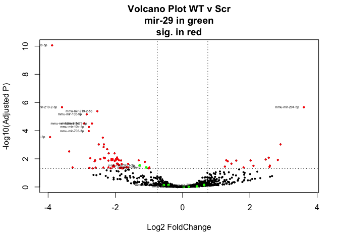

```r
plot(res$log2FoldChange,-log(res$padj,10),ylab="-log10(Adjusted P)",xlab="Log2 FoldChange",main=paste("Volcano Plot","WT v Scr\nmir-29 in green\nsig. in red"),pch=19,cex=0.4)
points(res[sig,"log2FoldChange"],-log(res[sig,"padj"],10),pch=19,cex=0.4,col="red")
text(res[sig[1:10],"log2FoldChange"],-log(res[sig[1:10],"padj"],10),pch=19,cex=0.4,pos=2,labels = rownames(res[sig[1:10],]))
points(res[rownames(mircounts)[grep("mir-29[a-z]",rownames(mircounts))],"log2FoldChange"],-log(res[rownames(mircounts)[grep("mir-29[a-z]",rownames(mircounts))],"padj"],10),pch=19,cex=0.6,col="green")
text(res[rownames(mircounts)[grep("mir-29[a-z]",rownames(mircounts))],"log2FoldChange"],-log(res[rownames(mircounts)[grep("mir-29[a-z]",rownames(mircounts))],"padj"],10),pch=19,cex=0.4,pos=2,labels =rownames(mircounts)[grep("mir-29[a-z]",rownames(mircounts))])
abline(h=-log10(p_threshold),lty=3)
abline(v=-lfc_threshold,lty=3)
abline(v=lfc_threshold,lty=3)
```

## Scatter Plot

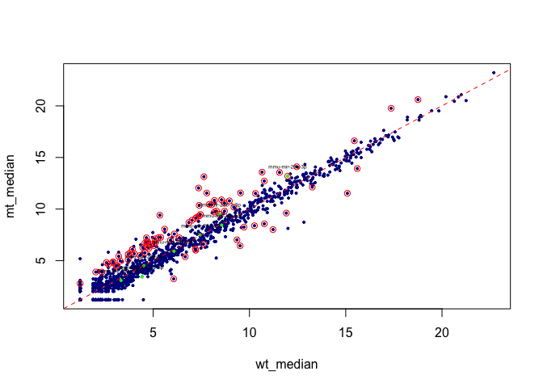

```r
wt_median = apply(vstcounts[,pdata$Genotype == "wt"],1,median)
mt_median = apply(vstcounts[,pdata$Genotype == "mut"],1,median)
plot(wt_median,mt_median,cex=0.4,pch=19,col="darkblue")
points(wt_median[grep("mir-29[a-z]",rownames(vstcounts))],mt_median[grep("mir-29[a-z]",rownames(vstcounts))],cex=0.4,pch=19,col="green")
points(wt_median[sig],mt_median[sig],cex=1,col="red")
text(wt_median[grep("mir-29[a-z]",rownames(vstcounts))],mt_median[grep("mir-29[a-z]",rownames(vstcounts))],cex=0.4,pos=3,labels=rownames(vstcounts)[grep("mir-29[a-z]",rownames(vstcounts))])
abline(a=0,b=1,lty=2,col="red")
```

Heatmap of significant hits.

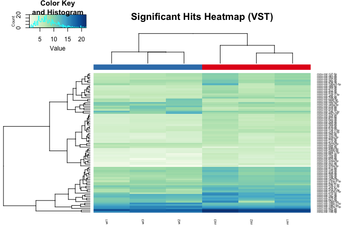

```r
heatmap.2(vstcounts[sig,],trace="none",ColSideColors = cond_colours,col=hmcol,margins=c(5,5),cexRow=0.5,cexCol=0.6,labCol=paste(rownames(pdata),pdata$SampleName,sep="\n"),main="Significant Hits Heatmap (VST)")
```

## Result output to text file

Let’s output the final results table with normalised expression values and stats listed

```r
write.table(cbind(as.matrix(counts(dds,normalized=T)[rownames(res),]),as.matrix(res)),"mouse_results.txt",quote=F,sep="\t")
```

## Length Analysis

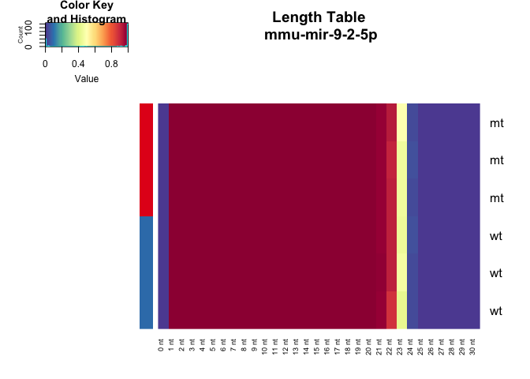

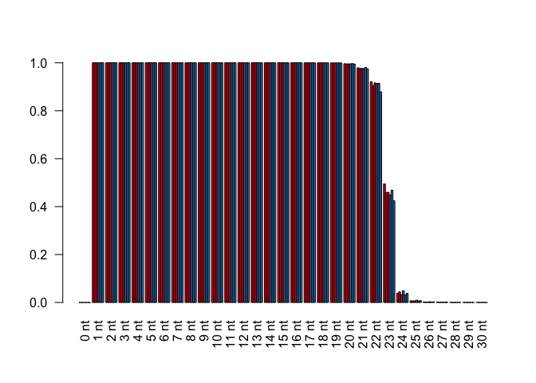

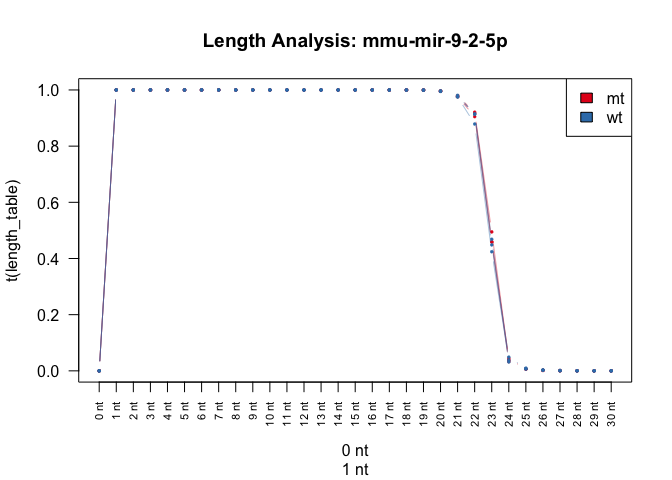

```
## [1] "mmu-mir-9-2-5p trimming-test 16-21 P-value:0.979147074753133 >>ns DF:33.9863112682457 T:-0.026331327322368 Conf Int 95:-0.001103504236752 to 0.00107527471498382"
## [1] "mmu-mir-9-2-5p trimming-test 17-22 P-value:0.997543317648514 >>ns DF:33.9975400557372 T:-0.00310172131199731 Conf Int 95:-0.00576215229455686 to 0.00574459012970759"
## [1] "mmu-mir-9-2-5p trimming-test 18-23 P-value:0.868021928599759 >>ns DF:33.3321144249497 T:0.167457519251251 Conf Int 95:-0.0214987735156065 to 0.0253568397471551"
## [1] "mmu-mir-9-2-5p tailing-test 21-26 P-value:0.969498108549098 >>ns DF:33.999812871166 T:0.0385203440628656 Conf Int 95:-0.289183558914827 to 0.300358071496801"
## [1] "mmu-mir-9-2-5p tailing-test 22-27 P-value:0.969632325471596 >>ns DF:33.9978075392212 T:0.0383507745822705 Conf Int 95:-0.28452829355675 to 0.29547356495224"
## [1] "mmu-mir-9-2-5p tailing-test 23-28 P-value:0.963322451065909 >>ns DF:33.987105833169 T:0.046324870345685 Conf Int 95:-0.233229795015377 to 0.244110583239036"
## [1] "mmu-mir-9-2-5p combined-test (16-28nt) P-value:0.238135870741399 >>ns DF:12 T:1.24151409363319 Conf Int 95:-0.00189261856948422 to 0.00690641521201209"
```

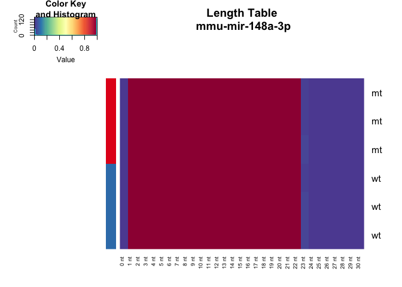

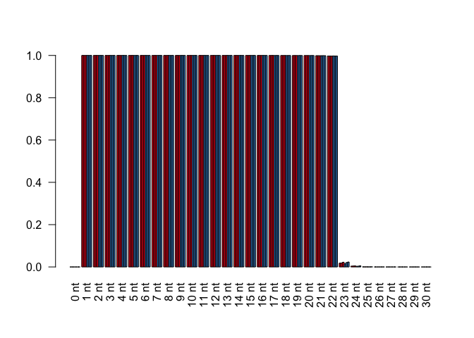

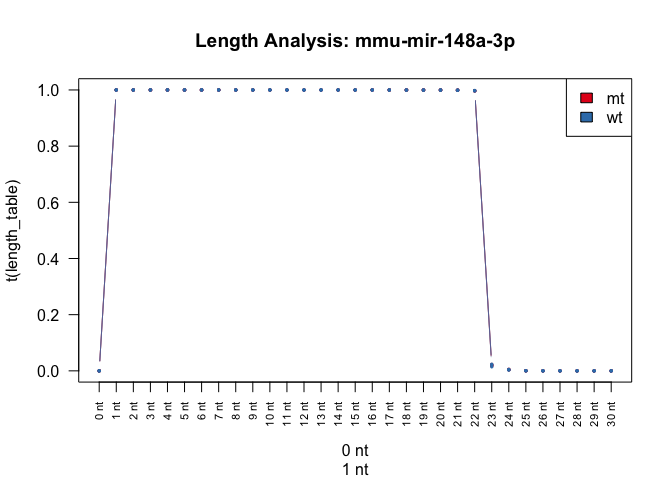

```
## [1] "mmu-mir-148a-3p trimming-test 16-21 P-value:0.355061167786251 >>ns DF:30.8263337491432 T:0.938939406094083 Conf Int 95:-6.03328717112049e-05 to 0.00016323361798593"
## [1] "mmu-mir-148a-3p trimming-test 17-22 P-value:0.634011657381611 >>ns DF:33.9992429598472 T:0.480411445922994 Conf Int 95:-0.000163308078772884 to 0.00026442074074543"
## [1] "mmu-mir-148a-3p trimming-test 18-23 P-value:0.98387447784671 >>ns DF:33.5600429059776 T:0.0203628873193764 Conf Int 95:-0.000658449964027967 to 0.000671772221667914"
## [1] "mmu-mir-148a-3p tailing-test 21-26 P-value:0.9996680157295 >>ns DF:33.9999974911181 T:0.000419150840056292 Conf Int 95:-0.345187869385356 to 0.345330288894428"
## [1] "mmu-mir-148a-3p tailing-test 22-27 P-value:0.99971287174773 >>ns DF:33.9999972388832 T:0.000362517317625601 Conf Int 95:-0.325950072608663 to 0.326066381081413"
## [1] "mmu-mir-148a-3p tailing-test 23-28 P-value:0.99964078082836 >>ns DF:33.999995153129 T:0.000453536603351561 Conf Int 95:-0.257762694248638 to 0.257877769881689"
## [1] "mmu-mir-148a-3p combined-test (16-28nt) P-value:0.239968636507565 >>ns DF:12 T:1.23638543418157 Conf Int 95:-3.80280539200181e-05 to 0.000137807267007839"
```

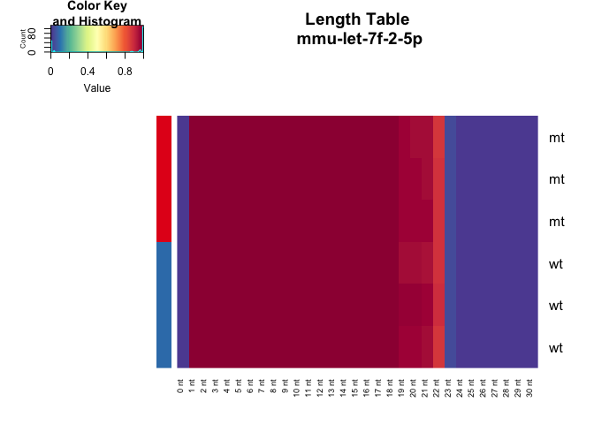

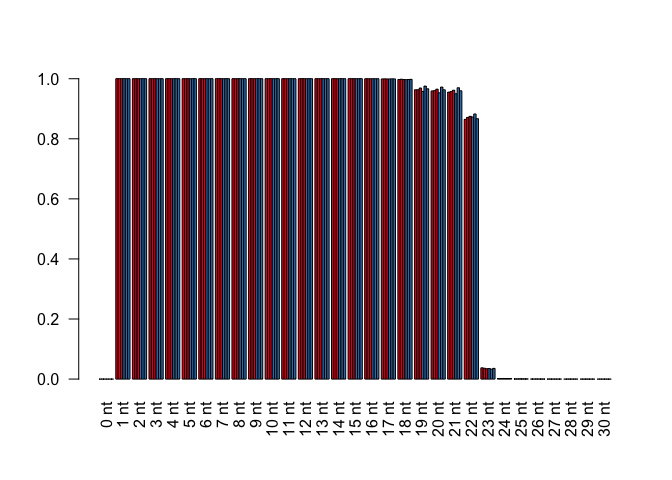

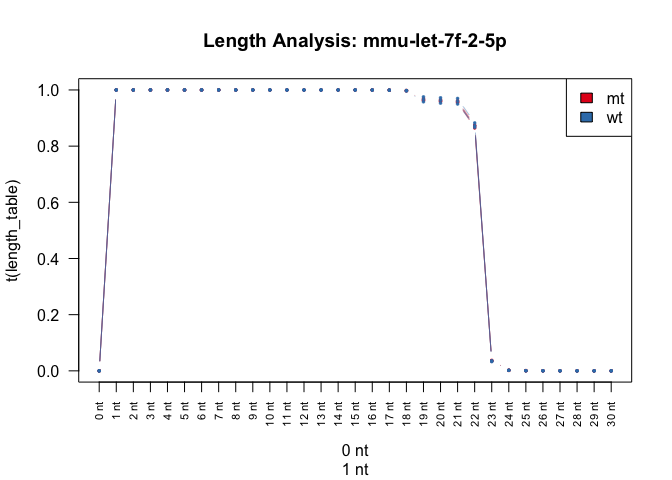

```
## [1] "mmu-let-7f-2-5p trimming-test 16-21 P-value:0.943810792007168 >>ns DF:33.9974420911757 T:-0.0710037811618578 Conf Int 95:-0.012234162564613 to 0.0114081360043994"
## [1] "mmu-let-7f-2-5p trimming-test 17-22 P-value:0.913389013473437 >>ns DF:33.9996036074929 T:-0.109577068855395 Conf Int 95:-0.0138690535099352 to 0.0124499534059278"
## [1] "mmu-let-7f-2-5p trimming-test 18-23 P-value:0.927226996467204 >>ns DF:33.9837793900387 T:-0.09201425154328 Conf Int 95:-0.0309868477819178 to 0.0283024444479046"
## [1] "mmu-let-7f-2-5p tailing-test 21-26 P-value:0.995530815031397 >>ns DF:33.9997122943032 T:-0.00564265566914789 Conf Int 95:-0.321783447028004 to 0.320001491031192"
## [1] "mmu-let-7f-2-5p tailing-test 22-27 P-value:0.996302361169858 >>ns DF:33.9996056548419 T:-0.00466851727525919 Conf Int 95:-0.299037621925798 to 0.297666859708043"
## [1] "mmu-let-7f-2-5p tailing-test 23-28 P-value:0.997226453803235 >>ns DF:33.99924646274 T:-0.00350178282864773 Conf Int 95:-0.225138218749477 to 0.224363677728302"
## [1] "mmu-let-7f-2-5p combined-test (16-28nt) P-value:0.183212085778741 >>ns DF:12 T:-1.41248912129883 Conf Int 95:-0.00128709407665642 to 0.000274644326572715"
```

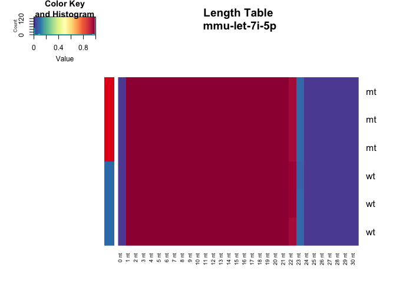

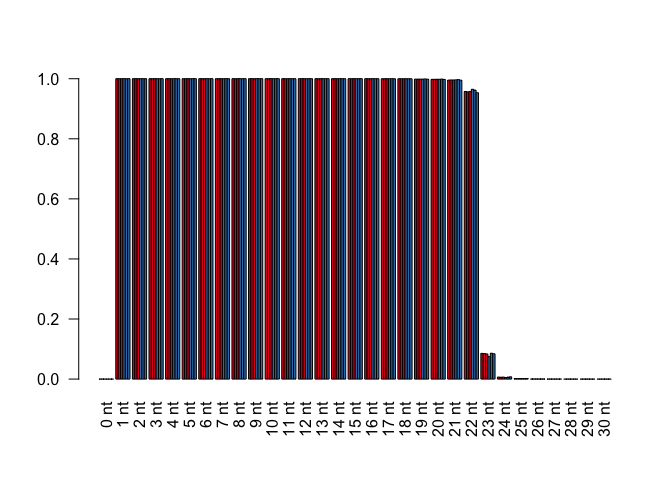

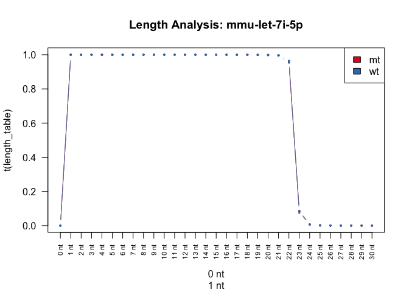

```
## [1] "mmu-let-7i-5p trimming-test 16-21 P-value:0.848743000061334 >>ns DF:33.7823651058229 T:-0.192191319045608 Conf Int 95:-0.000557712238783943 to 0.000461360425194253"
## [1] "mmu-let-7i-5p trimming-test 17-22 P-value:0.837499463693066 >>ns DF:33.8702563215943 T:-0.206677150605091 Conf Int 95:-0.00112614253757127 to 0.000918258424176481"
## [1] "mmu-let-7i-5p trimming-test 18-23 P-value:0.907473362525591 >>ns DF:33.8698272202658 T:-0.117098843104553 Conf Int 95:-0.0110775279980336 to 0.00987065513412996"
## [1] "mmu-let-7i-5p tailing-test 21-26 P-value:0.999631198394098 >>ns DF:33.999840334052 T:-0.000465635040593305 Conf Int 95:-0.333165212702236 to 0.333012575720575"
## [1] "mmu-let-7i-5p tailing-test 22-27 P-value:0.999811793155087 >>ns DF:33.9998092263479 T:-0.000237622880830643 Conf Int 95:-0.314373510878005 to 0.314300002410018"
## [1] "mmu-let-7i-5p tailing-test 23-28 P-value:0.999861400997893 >>ns DF:33.999565102234 T:0.000174989893530334 Conf Int 95:-0.245123861807625 to 0.245166079042673"
## [1] "mmu-let-7i-5p combined-test (16-28nt) P-value:0.913354484650761 >>ns DF:12 T:-0.111124698574519 Conf Int 95:-0.00078781932531294 to 0.000711357689153109"
```

[33 more figures not shown]

```
## [1] "mmu-mir-29b-2-5p trimming-test 16-21 P-value:0.739770903847523 >>ns DF:33.6088423229711 T:0.334914579067431 Conf Int 95:-0.0069217047304003 to 0.00965186346055899"
## [1] "mmu-mir-29b-2-5p trimming-test 17-22 P-value:0.815340029582888 >>ns DF:26.7262189259627 T:-0.23585920823868 Conf Int 95:-0.0166074911546283 to 0.0131845219669532"
## [1] "mmu-mir-29b-2-5p trimming-test 18-23 P-value:0.569940438324162 >>ns DF:25.7471855473381 T:-0.575513248514891 Conf Int 95:-0.0245184241779927 to 0.0137961282420745"
## [1] "mmu-mir-29b-2-5p tailing-test 21-26 P-value:0.904059325822727 >>ns DF:33.4208696686984 T:0.121453292406892 Conf Int 95:-0.193267005024468 to 0.21781911773121"
## [1] "mmu-mir-29b-2-5p tailing-test 22-27 P-value:0.874951010107516 >>ns DF:33.6620984902155 T:0.158575324035112 Conf Int 95:-0.242674414020189 to 0.283734748665069"
## [1] "mmu-mir-29b-2-5p tailing-test 23-28 P-value:0.862548008566446 >>ns DF:33.8701455511156 T:0.174453091911684 Conf Int 95:-0.250357624738798 to 0.297369269299617"
## [1] "mmu-mir-29b-2-5p combined-test (16-28nt) P-value:0.327837575732214 >>ns DF:12 T:1.02003308462982 Conf Int 95:-0.0114271574346663 to 0.0315450076068869"
```

```r
length_mouse=read.table("length_tables_mouse_mar_2017.txt",sep="\t",header=FALSE)
length_mouse$genotype=gsub("\\d+.lane.clean.uniquified.fa.gz","",gsub("mouse_","",length_mouse$V2))

mirlist=unique(c(rownames(counts(dds,normalized=T)[1:5,]),rownames(res[1:5,]),rownames(mircounts)[grep("mir-29[a-z]",rownames(mircounts))]))

for (i in 1:length(mirlist)){
mir=mirlist[i]

if (median(normcounts[mirlist[i],]) >= 50){
length_table=as.matrix(length_mouse[length_mouse$V1==mir,4:34])/apply(as.matrix(length_mouse[length_mouse$V1==mir,4:34]),1,max)
rownames(length_table)=length_mouse[length_mouse$V1==mir,"genotype"]

length_table=length_table[order(rownames(length_table)),]

colours = c("#E41A1C","#377EB8")[as.factor(rownames(length_table))]
names(colours)=as.factor(rownames(length_table))

heatmap.2(length_table,col=spectral,trace="none",Rowv=F,Colv=F,dendrogram="none",labCol=paste(c(0:30),"nt"),main=paste("Length Table\n",mir),RowSideColors=colours)

barplot(length_table,beside=T,col=colours,names=paste(c(0:30),"nt"),las=2)

matplot(t(length_table),type="b",col=colours,pch=19,cex=0.4,lty=1,lwd=0.4,main=paste("Length Analysis:",mir),xlab=paste(c(0:30),"nt"),las=2,xaxt="n")
axis(1, at = 1:31, labels = paste(c(0:30),"nt"), cex.axis = 0.7,las=2)
legend("topright",levels(as.factor(rownames(length_table))),fill=colours[levels(as.factor(rownames(length_table)))])


for (i in 16:18){
    j=i+5
    pvalue=NA
    pvalue_full=NA
    pvalue_full=t.test(length_table[1:3,i:j],length_table[4:6,i:j])
    pvalue=pvalue_full$p.value
    if (pvalue <= 0.05){
      sig="*"
    } else {
      sig="ns"
    }

    print(paste(mir," trimming-test ",i,"-",j," P-value:",pvalue," >>",sig, " DF:",pvalue_full$parameter, " T:",pvalue_full$statistic, " Conf Int 95:",  paste(pvalue_full$conf.int[1],pvalue_full$conf.int[2],sep=" to "),sep=""))

}

for (i in 21:23){
    j=i+5
    pvalue=NA
    pvalue_full=NA
    pvalue_full=t.test(length_table[1:3,i:j],length_table[4:6,i:j])
    pvalue=pvalue_full$p.value
    if (pvalue <= 0.05){
      sig="*"
    } else {
      sig="ns"
    }
    print(paste(mir," tailing-test ",i,"-",j," P-value:",pvalue," >>",sig, " DF:",pvalue_full$parameter, " T:",pvalue_full$statistic, " Conf Int 95:",  paste(pvalue_full$conf.int[1],pvalue_full$conf.int[2],sep=" to "),sep=""))
}

    #Trimming and Tailing Combined
    pvalue=NA
    pvalue_full=NA
    pvalue_full=t.test(as.numeric(rbind(apply(length_table[c(1:3),16:28],2,mean))),as.numeric(rbind(apply(length_table[c(4:6),16:28],2,mean))),paired=TRUE)
    pvalue=pvalue_full$p.value
    if (pvalue <= 0.05){
      sig="*"
    } else {
      sig="ns"
    }
    print(paste(mir," combined-test (16-28nt) P-value:",pvalue," >>",sig, " DF:",pvalue_full$parameter, " T:",pvalue_full$statistic, " Conf Int 95:",  paste(pvalue_full$conf.int[1],pvalue_full$conf.int[2],sep=" to "),sep=""))

}
}
```